# SPH 5104 Group Assignment: Group 1

# 7.2 Random Forest Classifier

```python
# Create the parameter grid

rf = RandomForestClassifier(random_state=42)

param_grid = {
    'n_estimators': [100, 200, 500, 800,1000],
    'max_features': ['auto', 'sqrt'],
    'max_depth' : [4,5,6,7,8,9],
    'criterion' :['gini', 'entropy']
}

#run the classifier using gridsearch and fit the model using training data
rf_classifier = GridSearchCV(estimator=rf, param_grid=param_grid, cv = 5, n_jobs = -1, verbose = 10)

rf_classifier.fit(X2_train_scaled, y2_train)

print("Tuned Random Forest Parameters: %s" % (rf_classifier.best_params_))
```

```
Fitting 5 folds for each of 120 candidates, totalling 600 fits
```

[output not shown]

```
Tuned Random Forest Parameters: {'criterion': 'gini', 'max_depth': 4, 'max_features': 'auto', 'n_estimators': 100}
```

```
[Parallel(n_jobs=-1)]: Done 600 out of 600 | elapsed:  3.9min finished
```

```
Accuracy: 0.9315751960085531

              precision    recall  f1-score   support

           0       0.93      1.00      0.96      1307
           1       0.00      0.00      0.00        96

    accuracy                           0.93      1403
   macro avg       0.47      0.50      0.48      1403
weighted avg       0.87      0.93      0.90      1403


Average 5-Fold CV Score: 0.9322 Standard deviation: 0.0005
```

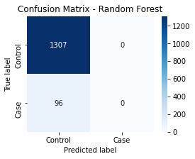

```python
#using the best parameters to train the rf model

best_rf = RandomForestClassifier(random_state=42, max_features='auto', n_estimators= 100, max_depth=4, criterion='gini')

best_rf.fit(X2_train_scaled, y2_train)

yRF_pred = best_rf.predict(X2_test_scaled)

print('Accuracy:', metrics.accuracy_score(yRF_pred,y2_test))

## 5-fold cross-validation
cv_scores2 =cross_val_score(best_rf, X2, y2, cv=5)

# Print the 5-fold cross-validation scores
print()
print(classification_report(y2_test, yRF_pred, zero_division=0))
print()
print("Average 5-Fold CV Score: {}".format(round(np.mean(cv_scores2),4)),"Standard deviation: {}".format(round(np.std(cv_scores2),4)))

#plot the confusion matrix
plt.figure(figsize=(4,3))
ConfMatrix2 = confusion_matrix(y2_test,best_rf.predict(X2_test_scaled))
sns.heatmap(ConfMatrix2,annot=True, cmap="Blues", fmt="d",
            xticklabels = ['Control', 'Case'],
            yticklabels = ['Control', 'Case'])
plt.ylabel('True label')
plt.xlabel('Predicted label')
plt.title("Confusion Matrix - Random Forest");
```

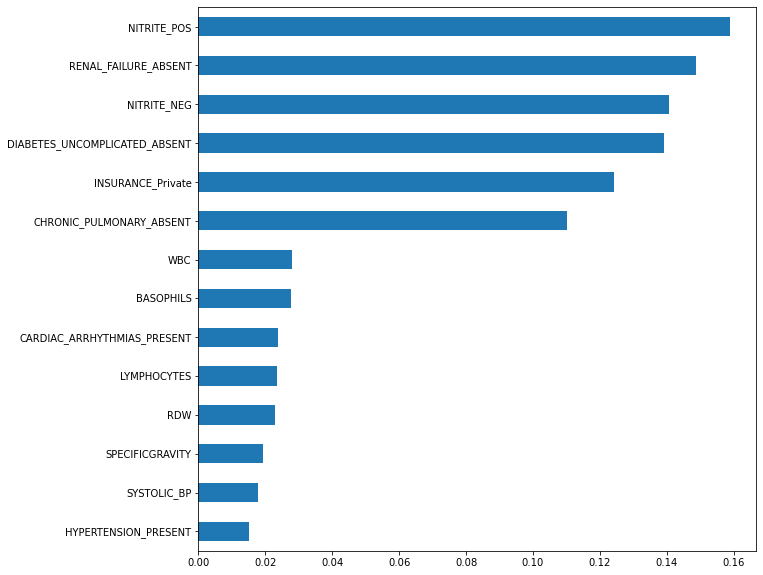

```python
#look at the most important features based on the best rf model
fig, (ax) = plt.subplots(ncols=1, figsize=(10,10))

rf_feat_importances = pd.Series(best_rf.feature_importances_, index=X2.columns)

rf_feat_importances.nlargest(30).sort_values(ascending=True).plot(kind='barh')
plt.show()
```

```python
#use the Random Forest Classifier model to predict probabilities (of 0 and 1) for each row of the testing data
rfprob = best_rf.predict_proba(X2_test_scaled)

#put the predicted probabilities into a dataframe
#For probability values, first value is probability of outcome = 0, second value is probability of outcome = 1

rfpredprob = pd.DataFrame({"probabilities":list(rfprob)})
```

```python
#insert a column to store the random forest classifier probability values
X2_testdf['RFPROBABILITIES'] = rfpredprob.values
```

```python
#create 2 new columns with probability of control and case, and drop the rfprobabilities column
X2_testdf[['RF_PROB_CONTROL','RF_PROB_CASE']] = pd.DataFrame(X2_testdf.RFPROBABILITIES.values.tolist(), index= X2_testdf.index)
X2_testdf.drop(['RFPROBABILITIES'], axis = 1, inplace=True)
```

# 7.3 XG Boost Classifier

```python
xgb = XGBClassifier(objective = 'binary:logistic')

param_grid = [{'max_depth': range(4,10,2),'min_child_weight':range(1,6,2), 'n_estimators':[100,200,500], 'eta':[0.01,0.1,1], 'colsample_bytree':[0.8,1], 'subsample':[0.8,1] }]

#create svm classifier
xgb_classifier = GridSearchCV(xgb, param_grid, cv = 5, refit = True, verbose = 10, scoring = 'roc_auc', n_jobs=-1)


# fitting the model for grid search
xgb_classifier.fit(X2_train_scaled, y2_train)

print("Tuned XGB Parameters: %s" % (xgb_classifier.best_params_))
```

```
Fitting 5 folds for each of 324 candidates, totalling 1620 fits
```

[output not shown]

```
Tuned XGB Parameters: {'colsample_bytree': 1, 'eta': 0.01, 'max_depth': 4, 'min_child_weight': 1, 'n_estimators': 500, 'subsample': 1}
```

```
Accuracy: 0.9315751960085531

              precision    recall  f1-score   support

           0       0.93      1.00      0.96      1307
           1       0.00      0.00      0.00        96

    accuracy                           0.93      1403
   macro avg       0.47      0.50      0.48      1403
weighted avg       0.87      0.93      0.90      1403


Average 5-Fold CV Score: 0.9322 Standard deviation: 0.0005
```

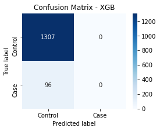

```python
#using the best parameters to train the XG Boost model

best_xgb = XGBClassifier(max_depth=4, n_estimators=500, eta = 0.01, colsample_bytree = 1, subsample = 1, min_child_weight = 1, verbose = True)

best_xgb.fit(X2_train_scaled, y2_train)

yXGB_pred = best_xgb.predict(X2_test_scaled)

print('Accuracy:', metrics.accuracy_score(yXGB_pred,y2_test))

## 5-fold cross-validation
cv_scores3 =cross_val_score(best_xgb, X2, y2, cv=5)

# Print the 5-fold cross-validation scores
print()
print(classification_report(y2_test, yXGB_pred, zero_division=0))
print()
print("Average 5-Fold CV Score: {}".format(round(np.mean(cv_scores3),4)),"Standard deviation: {}".format(round(np.std(cv_scores3),4)))

#plot the confusion matrix
plt.figure(figsize=(4,3))
ConfMatrix3 = confusion_matrix(y2_test, best_xgb.predict(X2_test_scaled))
sns.heatmap(ConfMatrix3,annot=True, cmap="Blues", fmt="d",
            xticklabels = ['Control', 'Case'],
            yticklabels = ['Control', 'Case'])
plt.ylabel('True label')
plt.xlabel('Predicted label')
plt.title("Confusion Matrix - XGB");
```

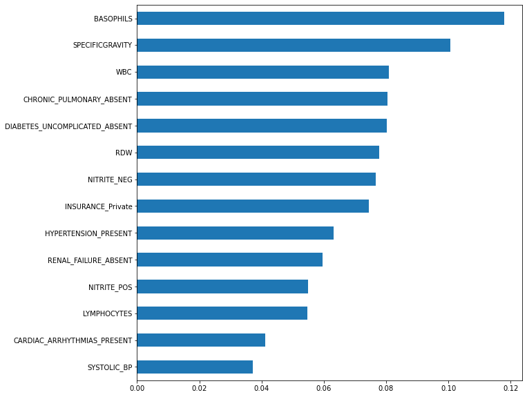

```python
#look at the most important features based on the best xgb model

fig, (ax) = plt.subplots(ncols=1, figsize=(10,10))

xgb_feat_importances = pd.Series(best_xgb.feature_importances_, index=X2.columns)

xgb_feat_importances.nlargest(30).sort_values(ascending=True).plot(kind='barh')
plt.show()
```

```python
#use the XG Boost Classifier model to predict probabilities (of 0 and 1) for each row of the testing data
xgbprob = best_xgb.predict_proba(X2_test_scaled)

#put the predicted probabilities into a dataframe
#For probability values, first value is probability of outcome = 0, second value is probability of outcome = 1

xgbpredprob = pd.DataFrame({"probabilities":list(xgbprob)})
```

```python
#insert a column to store the XG Boost probability values
X2_testdf['XGBPROBABILITIES'] = xgbpredprob.values
```

```python
#create 2 new columns with probability of control and case, and drop the xgbprobabilities column
X2_testdf[['XGB_PROB_CONTROL','XGB_PROB_CASE']] = pd.DataFrame(X2_testdf.XGBPROBABILITIES.values.tolist(), index= X2_testdf.index)
X2_testdf.drop(['XGBPROBABILITIES'], axis = 1, inplace=True)
```

# 7.4 Light GBM

```python
# Build LightGBMclassifier
lgb = LGBMClassifier(objective = 'binary')
# Fit the model with training data

param_grid = [{'learning_rate': (0.005,0.01, 0.1),'n_estimators':range(200, 500,100), 'num_leaves':range(20,60,10), 'max_bin': [512], 'eta':[0.01,0.1], 'colsample_bytree':[0.8,1], 'subsample':[0.8,1]}]

lgb_classifier = GridSearchCV(lgb, param_grid, cv = 5, scoring= 'roc_auc', n_jobs=-1, verbose = 10)


lgb_classifier.fit(X2_train_scaled,y2_train)

print("Tuned LGBM Parameters: %s" % (lgb_classifier.best_params_))
```

```
Fitting 5 folds for each of 288 candidates, totalling 1440 fits
```

[output not shown]

```
Tuned LGBM Parameters: {'colsample_bytree': 1, 'eta': 0.01, 'learning_rate': 0.1, 'max_bin': 512, 'n_estimators': 200, 'num_leaves': 20, 'subsample': 0.8}
```

```
Accuracy: 0.9308624376336422

              precision    recall  f1-score   support

           0       0.93      1.00      0.96      1307
           1       0.00      0.00      0.00        96

    accuracy                           0.93      1403
   macro avg       0.47      0.50      0.48      1403
weighted avg       0.87      0.93      0.90      1403


Average 5-Fold CV Score: 0.9316 Standard deviation: 0.0014
```

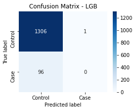

```python
#using the best parameters to train the Light GBM  model

best_lgb = LGBMClassifier(n_estimators = 200, num_leaves=20, eta = 0.01, colsample_bytree = 0.1, subsample = 0.8, learning_rate = 0.1, max_bin = 512, verbose = 10)

best_lgb.fit(X2_train_scaled, y2_train)

yLGB_pred = best_lgb.predict(X2_test_scaled)

# CV score
lgb_cv =cross_val_score(best_lgb, X2, y2, cv=5)

print('Accuracy:', metrics.accuracy_score(yLGB_pred,y2_test))

# Print the 5-fold cross-validation scores
print()
print(classification_report(y2_test, yLGB_pred))
print()
print("Average 5-Fold CV Score: {}".format(round(np.mean(lgb_cv),4)),"Standard deviation: {}".format(round(np.std(lgb_cv),4)))

#plot the confusion matrix
plt.figure(figsize=(4,3))
ConfMatrix4 = confusion_matrix(y2_test,best_lgb.predict(X2_test_scaled))
sns.heatmap(ConfMatrix4,annot=True, cmap="Blues", fmt="d",
            xticklabels = ['Control', 'Case'],
            yticklabels = ['Control', 'Case'])
plt.ylabel('True label')
plt.xlabel('Predicted label')
plt.title("Confusion Matrix - LGB");
```

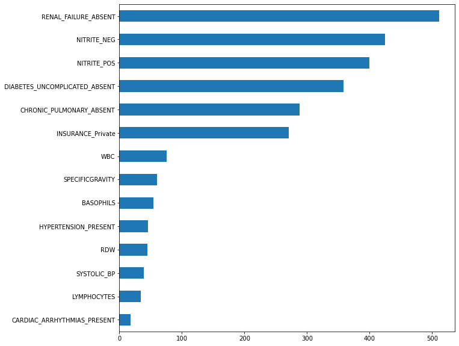

```python
#look at the most important features based on the best lgb model

fig, (ax) = plt.subplots(ncols=1, figsize=(10,10))

lgb_feat_importances = pd.Series(best_lgb.feature_importances_, index=X2.columns)

lgb_feat_importances.nlargest(30).sort_values(ascending=True).plot(kind='barh')
plt.show()
```

```python
#use the Light GBM Classifier model to predict probabilities (of 0 and 1) for each row of the testing data
lgbprob = best_lgb.predict_proba(X2_test_scaled)

#put the predicted probabilities into a dataframe
#For probability values, first value is probability of outcome = 0, second value is probability of outcome = 1

lgbpredprob = pd.DataFrame({"probabilities":list(lgbprob)})
```

```python
#insert a column to store the LGBM probability values
X2_testdf['LGBMPROBABILITIES'] = lgbpredprob.values
```

```python
#create 2 new columns with probability of control and case, and drop the lgbmprobabilities column
X2_testdf[['LGBM_PROB_CONTROL','LGBM_PROB_CASE']] = pd.DataFrame(X2_testdf.LGBMPROBABILITIES.values.tolist(), index= X2_testdf.index)
X2_testdf.drop(['LGBMPROBABILITIES'], axis = 1, inplace=True)
```

# 7.5 Model Evaluation - Plot AUC curve and predicted probabilities

```python
#get the predic_proba values (i.e., probabilities of classification) for predicting whether a patient will be a CASE

y_pred_proba_LR = best_logreg2.predict_proba(X2_test_scaled)[::,1]
fpr1, tpr1, _ = metrics.roc_curve(y2_test,  y_pred_proba_LR)
auc1 = metrics.roc_auc_score(y2_test, y_pred_proba_LR)

y_pred_proba_RF = best_rf.predict_proba(X2_test_scaled)[::,1]
fpr2, tpr2, _ = metrics.roc_curve(y2_test,  y_pred_proba_RF)
auc2 = metrics.roc_auc_score(y2_test, y_pred_proba_RF)

y_pred_proba_XGB = best_xgb.predict_proba(X2_test_scaled)[::,1]
fpr3, tpr3, _ = metrics.roc_curve(y2_test,  y_pred_proba_XGB)
auc3 = metrics.roc_auc_score(y2_test, y_pred_proba_XGB)

y_pred_proba_LGBM = best_lgb.predict_proba(X2_test_scaled)[::,1]
fpr4, tpr4, _ = metrics.roc_curve(y2_test,  y_pred_proba_LGBM)
auc4 = metrics.roc_auc_score(y2_test, y_pred_proba_LGBM)
```

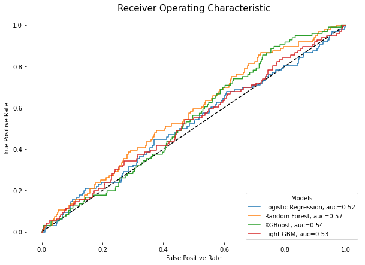

```python
#Plot the ROC and AUC

plt.figure(figsize=(10,7))
plt.plot([0, 1], [0, 1], 'k--')
plt.plot(fpr1,tpr1,label="Logistic Regression, auc="+str(round(auc1,2)))

plt.plot(fpr2,tpr2,label="Random Forest, auc="+str(round(auc2,2)))

plt.plot(fpr3,tpr3,label="XGBoost, auc="+str(round(auc3,2)))

plt.plot(fpr4,tpr4,label="Light GBM, auc="+str(round(auc4,2)))


plt.legend(loc=4, title='Models', facecolor='white')
plt.xlabel('False Positive Rate')
plt.ylabel('True Positive Rate')
plt.title('Receiver Operating Characteristic', size=15)
plt.box(False)
plt.savefig('ImageName', format='png', dpi=200, transparent=True);
```

```python
#Compare the cross validated models
# Append different best classifier models into a list
models = []

# Logistic Regression
models.append(('logreg',best_logreg2))

# Random Forest Classifier
models.append(('randomforest',best_rf))

#XGBoost
models.append(('xgboost',best_xgb))

#LightGBM
models.append(('LightGBM',best_lgb))

# Evaluate each model
results = []
names = []
scoring = 'accuracy'

for name, model in models:
    cv_results = cross_val_score(model, X2, y2, cv=5, scoring=scoring)
    results.append(cv_results)
    names.append(name)
    msg = "%s: %f (%f)" % (name, cv_results.mean(), cv_results.std())
    print(msg)
```

```
logreg: 0.932193 (0.000524)
randomforest: 0.932193 (0.000524)
xgboost: 0.932193 (0.000524)
LightGBM: 0.931551 (0.001353)
```

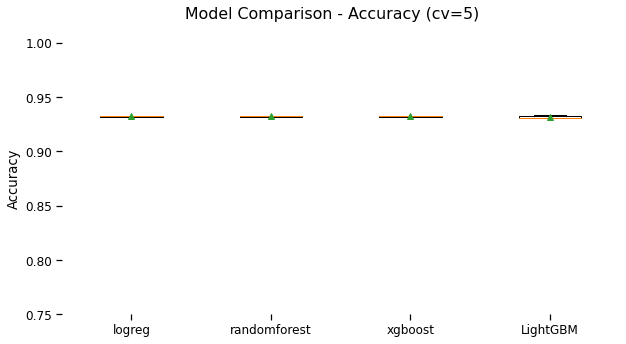

```python
from matplotlib import pyplot
# Plot all the accuracy results vs. each model
#(model type on the x-axis and accuracy on the y-axis).
fig = pyplot.figure(figsize=(10,5))
sns.set_context('notebook', font_scale=1.1)
fig.suptitle('Model Comparison - Accuracy (cv=5)')
ax = fig.add_subplot(111)
pyplot.boxplot(results, showmeans=True)
ax.set_xticklabels(names)
ax.set_ylabel('Accuracy')
ax.set_ylim([0.75,1])
plt.box(False)
plt.savefig('ImageName', format='png', dpi=200, transparent=True);
```

```python
#compare the classification report scores
classreport = pd.DataFrame({'model': ['Logistic_Regression','Random_Forest','XGBoost','LightGBM'], 'F1':[0.90, 0.90, 0.90,0.90], 'Precision':[0.87, 0.87, 0.87,0.87], 'Recall':[0.93,0.93,0.93,0.93]})
classreport
```

|  | model | F1 | Precision | Recall |
| --- | --- | --- | --- | --- |
| 0 | Logistic_Regression | 0.900 | 0.870 | 0.930 |
| 1 | Random_Forest | 0.900 | 0.870 | 0.930 |
| 2 | XGBoost | 0.900 | 0.870 | 0.930 |
| 3 | LightGBM | 0.900 | 0.870 | 0.930 |

It is peculiar that for all 4 models, the F1, precision and recall scores are exactly the same

# 8. Follow up analysis

# As model accuracy scores are very similar and F1 scores are identical across models, we will use the AUC curve to select the best model

# Based on the AUC curve, we select the Random Forest Classifier model as the best model for predicting the probability of whether a patient will be a case or not

# 8.1 Identifying the traits of CASE based on Random Forest Classifier model

```python
X2_testdf.head()
```

|  | RENAL_FAILURE_ABSENT | NITRITE_POS | NITRITE_NEG | CHRONIC_PULMONARY_ABSENT | INSURANCE_Private | DIABETES_UNCOMPLICATED_ABSENT | CARDIAC_ARRHYTHMIAS_PRESENT | HYPERTENSION_PRESENT | SYSTOLIC_BP | RDW | SPECIFICGRAVITY | BASOPHILS | LYMPHOCYTES | WBC | LR_PROB_CONTROL | LR_PROB_CASE | RF_PROB_CONTROL | RF_PROB_CASE | XGB_PROB_CONTROL | XGB_PROB_CASE | LGBM_PROB_CONTROL | LGBM_PROB_CASE |
| --- | --- | --- | --- | --- | --- | --- | --- | --- | --- | --- | --- | --- | --- | --- | --- | --- | --- | --- | --- | --- | --- | --- |
| 6216 | 1 | 0 | 1 | 1 | 0 | 1 | 0 | 0 | 93.000 | 22.000 | 1.011 | 0.200 | 6.100 | 9.000 | 0.822 | 0.178 | 0.936 | 0.064 | 0.969 | 0.031 | 0.997 | 0.003 |
| 20674 | 0 | 0 | 0 | 1 | 0 | 1 | 1 | 1 | 141.000 | 16.100 | 1.016 | 0.300 | 9.100 | 6.900 | 0.789 | 0.211 | 0.908 | 0.092 | 0.862 | 0.138 | 0.906 | 0.094 |
| 20148 | 0 | 0 | 0 | 1 | 1 | 1 | 1 | 1 | 125.000 | 13.800 | 1.016 | 0.300 | 11.600 | 13.800 | 0.814 | 0.186 | 0.940 | 0.060 | 0.951 | 0.049 | 0.924 | 0.076 |
| 16591 | 1 | 0 | 1 | 1 | 1 | 1 | 1 | 1 | 128.000 | 15.600 | 1.020 | 0.200 | 10.700 | 9.900 | 0.880 | 0.120 | 0.923 | 0.077 | 0.907 | 0.093 | 0.932 | 0.068 |
| 4074 | 0 | 0 | 1 | 1 | 0 | 1 | 1 | 1 | 93.000 | 14.500 | 1.010 | 0.200 | 31.200 | 15.500 | 0.830 | 0.170 | 0.931 | 0.069 | 0.955 | 0.045 | 0.953 | 0.047 |

```
<function matplotlib.pyplot.show(*args, **kw)>
```

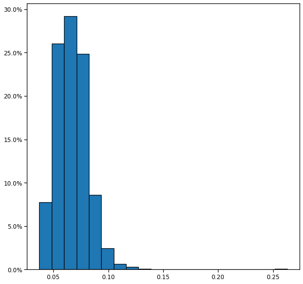

```python
#plot the probability distribution of defaulting from the Random Forest Model
from matplotlib.ticker import PercentFormatter
plt.figure(figsize=(10,10))

plt.hist(X2_testdf['RF_PROB_CASE'], weights=np.ones(len(X2_testdf['RF_PROB_CASE'])) / len(X2_testdf['RF_PROB_CASE']), bins = 20, edgecolor='black', linewidth=1.2)

plt.gca().yaxis.set_major_formatter(PercentFormatter(1))

plt.show
```

```python
#Bin the risk group based on the arbitrary cutoffs

X2_testdf['RISK'] = pd.cut(X2_testdf['RF_PROB_CASE'], bins=[0.000, 0.100, 0.600,1.000], labels=['LOW_RISK','MEDIUM_RISK','HIGH_RISK'])

X2_testdf['RISK'].value_counts()
```

```
LOW_RISK       1382
MEDIUM_RISK      21
HIGH_RISK         0
Name: RISK, dtype: int64
```

# 8.2 Look at the counts for the risk groups, focus on medium and high risk

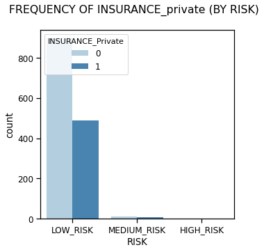

```python
#Get count plots for risk by INSURANCE_private

f, axes = plt.subplots(figsize=(5, 5), facecolor='white')
f.suptitle('FREQUENCY OF INSURANCE_private (BY RISK)')
ax1 = sns.countplot(x="RISK", hue="INSURANCE_Private", data=X2_testdf, palette="Blues")
```

Lower counts of private insurance for those in medium risk

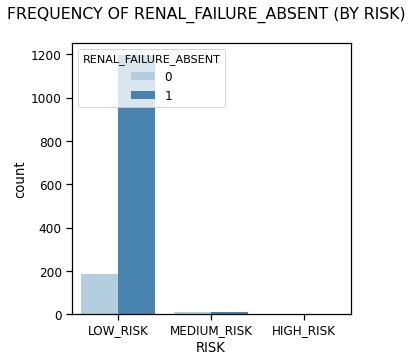

```python
#Get count plots for risk by absence of renal failure

f, axes = plt.subplots(figsize=(5, 5), facecolor='white')
f.suptitle('FREQUENCY OF RENAL_FAILURE_ABSENT (BY RISK)')
ax1 = sns.countplot(x="RISK", hue="RENAL_FAILURE_ABSENT", data=X2_testdf, palette="Blues")
```

Higher counts of no renal failure for those in medium risk group

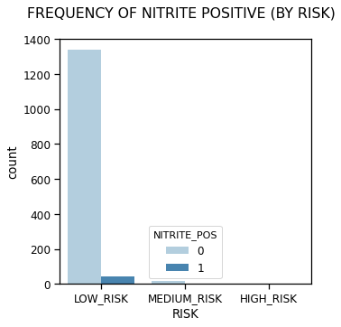

```python
#Get count plots for risk by Nitrite_POS
f, axes = plt.subplots(figsize=(5, 5), facecolor='white')
f.suptitle('FREQUENCY OF NITRITE POSITIVE (BY RISK)')
ax1 = sns.countplot(x="RISK", hue="NITRITE_POS", data=X2_testdf, palette="Blues")
```

Lower counts of positive nitrite levels for those in medium risk group

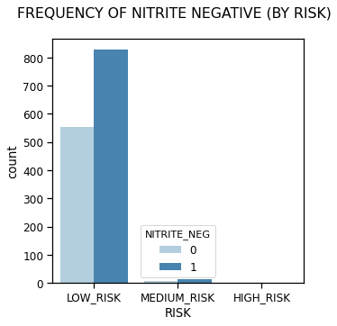

```python
#Get count plots for risk by absence of renal failure

f, axes = plt.subplots(figsize=(5, 5), facecolor='white')
f.suptitle('FREQUENCY OF NITRITE NEGATIVE (BY RISK)')
ax1 = sns.countplot(x="RISK", hue="NITRITE_NEG", data=X2_testdf, palette="Blues")
```

Higher counts of negative nitrite levels for medium risk patients

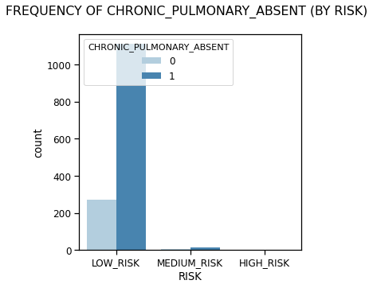

```python
#Get count plots for risk by absence of chronic pulmonary

f, axes = plt.subplots(figsize=(5, 5), facecolor='white')
f.suptitle('FREQUENCY OF CHRONIC_PULMONARY_ABSENT (BY RISK)')
ax1 = sns.countplot(x="RISK", hue="CHRONIC_PULMONARY_ABSENT", data=X2_testdf, palette="Blues")
```

Higher counts of NO chronic pulmonary issues for those in medium risk group

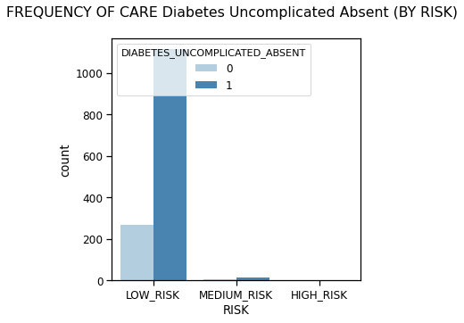

```python
#Get count plots for risk by Diasbetes Uncomplicated Absent

f, axes = plt.subplots(figsize=(5, 5), facecolor='white')
f.suptitle('FREQUENCY OF CARE Diabetes Uncomplicated Absent (BY RISK)')
ax1 = sns.countplot(x="RISK", hue="DIABETES_UNCOMPLICATED_ABSENT", data=X2_testdf, palette="Blues")
```

Higher counts of NO diabetes uncomplicated for those in medium risk group

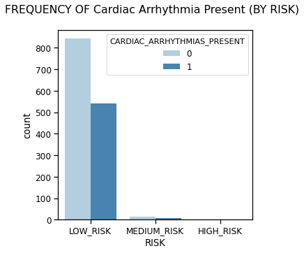

```python
#Get count plots for risk by Cardiac Arrhythmia Present

f, axes = plt.subplots(figsize=(5, 5), facecolor='white')
f.suptitle('FREQUENCY OF Cardiac Arrhythmia Present (BY RISK)')
ax1 = sns.countplot(x="RISK", hue="CARDIAC_ARRHYTHMIAS_PRESENT", data=X2_testdf, palette="Blues")
```

Lower count of presence of cardiac arrhythmias for those in medium risk group

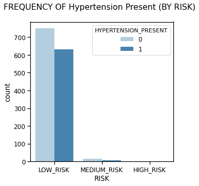

```python
#Get count plots for risk by Hypertension Present

f, axes = plt.subplots(figsize=(5, 5), facecolor='white')
f.suptitle('FREQUENCY OF Hypertension Present (BY RISK)')
ax1 = sns.countplot(x="RISK", hue="HYPERTENSION_PRESENT", data=X2_testdf, palette="Blues")
```

Lower counts of presence of hypertension for those in medium risk group

```python
#find out the mean values of the continuous variables for the medium risk group

#Select the medium risk group
mediumrisk = X2_testdf.loc[X2_testdf['RISK'] == 'MEDIUM_RISK']
```

```python
#select the continuous columns
mediumriskcont = mediumrisk[['SYSTOLIC_BP','RDW','SPECIFICGRAVITY','BASOPHILS','LYMPHOCYTES','WBC']]

mediumriskcont.describe()
```

|  | SYSTOLIC_BP | RDW | SPECIFICGRAVITY | BASOPHILS | LYMPHOCYTES | WBC |
| --- | --- | --- | --- | --- | --- | --- |
| count | 21.000 | 21.000 | 21.000 | 21.000 | 21.000 | 21.000 |
| mean | 150.333 | 17.243 | 1.016 | 0.705 | 15.781 | 7.024 |
| std | 43.457 | 1.921 | 0.011 | 1.282 | 18.951 | 5.011 |
| min | 42.000 | 14.100 | 1.001 | 0.000 | 4.000 | 0.400 |
| 25% | 128.000 | 16.100 | 1.010 | 0.100 | 6.800 | 4.000 |
| 50% | 139.000 | 16.700 | 1.015 | 0.300 | 10.500 | 5.900 |
| 75% | 187.000 | 17.800 | 1.017 | 1.000 | 17.000 | 7.700 |
| max | 219.000 | 21.100 | 1.049 | 6.000 | 94.000 | 18.900 |

we can use the mean scores of these continuous variables as a threshold for patients who are at risk of becoming a case

# 8.3 Try SMOTE for unbalanced dataset - to increase number of minority (ie number of cases)

```python
print("Before OverSampling, counts of Case label '1': {}".format(sum(y2_train == 1)))
print("Before OverSampling, counts of Control label '0': {} \n".format(sum(y2_train == 0)))

# import SMOTE module from imblearn library
# pip install imblearn (if you don't have imblearn in your system)
from imblearn.over_sampling import SMOTE
sm = SMOTE(random_state = 2)
X_train_smote, y_train_smote = sm.fit_sample(X2_train_scaled, y2_train.ravel())

print('After OverSampling, the shape of X2_train: {}'.format(X_train_smote.shape))
print('After OverSampling, the shape of y2_train: {} \n'.format(y_train_smote.shape))

print("After OverSampling, counts of Case label '1': {}".format(sum(y_train_smote == 1)))
print("After OverSampling, counts of Control label '0': {}".format(sum(y_train_smote == 0)))
```

```
Before OverSampling, counts of Case label '1': 221
Before OverSampling, counts of Control label '0': 3051

After OverSampling, the shape of X2_train: (6102, 14)
After OverSampling, the shape of y2_train: (6102,)

After OverSampling, counts of Case label '1': 3051
After OverSampling, counts of Control label '0': 3051
```

```python
#Create the parameter grid

rf = RandomForestClassifier(random_state=42)

param_grid = {
    'n_estimators': [100, 200, 500,800],
    'max_features': ['auto', 'sqrt'],
    'max_depth' : [4,5,6,7,8,9],
    'criterion' :['gini', 'entropy']
}

#run the classifier using gridsearch and fit the model using training data
rf_classifier = GridSearchCV(estimator=rf, param_grid=param_grid, cv = 5, n_jobs = -1, verbose = 10)

rf_classifier.fit(X_train_smote, y_train_smote.ravel())

print("Tuned Random Forest Parameters: %s" % (rf_classifier.best_params_))
```

```
Fitting 5 folds for each of 96 candidates, totalling 480 fits
```

[output not shown]

```
Tuned Random Forest Parameters: {'criterion': 'gini', 'max_depth': 9, 'max_features': 'auto', 'n_estimators': 500}
```

```
Accuracy: 0.9315751960085531

              precision    recall  f1-score   support

         0.0       0.93      1.00      0.96      1307
         1.0       0.00      0.00      0.00        96

    accuracy                           0.93      1403
   macro avg       0.47      0.50      0.48      1403
weighted avg       0.87      0.93      0.90      1403


Average 5-Fold CV Score: 0.9322 Standard deviation: 0.0005
```

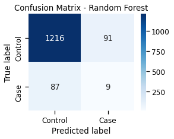

```python
#using the best parameters to train the rf model

best_rf_smote = RandomForestClassifier(random_state=42, max_features='auto', n_estimators= 500, max_depth=9, criterion='gini')

best_rf_smote.fit(X_train_smote, y_train_smote.ravel())

yRFsmote_pred = best_rf.predict(X2_test_scaled)

print('Accuracy:', metrics.accuracy_score(yRFsmote_pred,y2_test))

## 5-fold cross-validation
cv_scores5 =cross_val_score(best_rf, X2, y2, cv=5)

# Print the 5-fold cross-validation scores
print()
print(classification_report(y2_test, yRFsmote_pred))
print()
print("Average 5-Fold CV Score: {}".format(round(np.mean(cv_scores5),4)),"Standard deviation: {}".format(round(np.std(cv_scores5),4)))

#plot the confusion matrix
plt.figure(figsize=(4,3))
ConfMatrix5 = confusion_matrix(y2_test,best_rf_smote.predict(X2_test_scaled))
sns.heatmap(ConfMatrix5,annot=True, cmap="Blues", fmt="d",
            xticklabels = ['Control', 'Case'],
            yticklabels = ['Control', 'Case'])
plt.ylabel('True label')
plt.xlabel('Predicted label')
plt.title("Confusion Matrix - Random Forest");
```

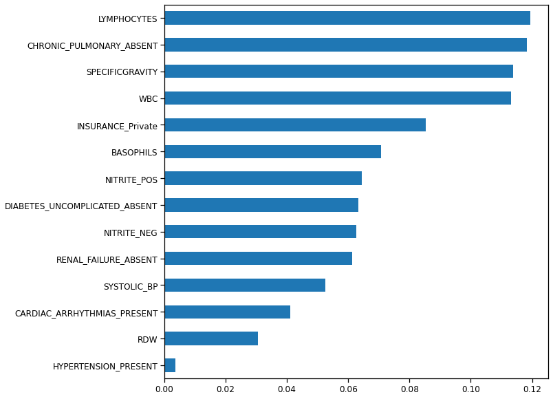

```python
#look at the most important features based on the best rf model
fig, (ax) = plt.subplots(ncols=1, figsize=(10,10))

rf_smote_feat_importances = pd.Series(best_rf_smote.feature_importances_, index=X2.columns)

rf_smote_feat_importances.nlargest(30).sort_values(ascending=True).plot(kind='barh')
plt.show()
```

```python
#use the Random Forest Classifier model to predict probabilities (of 0 and 1) for each row of the testing data
rfprob_smote = best_rf_smote.predict_proba(X2_test_scaled)

#put the predicted probabilities into a dataframe
#For probability values, first value is probability of outcome = 0, second value is probability of outcome = 1

rf_smotepredprob = pd.DataFrame({"probabilities":list(rfprob_smote)})
```

```python
#insert a column to store the XG Boost with SMOTE probability values
X2_testdf['RF_SMOTE_PROBABILITIES'] = rf_smotepredprob.values
```

```python
#create 2 new columns with probability of control and case, and drop the xgb2probabilities column
X2_testdf[['RF_SMOTE_PROB_CONTROL','RF_SMOTE_PROB_CASE']] = pd.DataFrame(X2_testdf.RF_SMOTE_PROBABILITIES.values.tolist(), index= X2_testdf.index)
X2_testdf.drop(['RF_SMOTE_PROBABILITIES'], axis = 1, inplace=True)
```

```python
#get the predic_proba values (i.e., probabilities of classification)

y_pred_proba_RF_SMOTE = best_rf_smote.predict_proba(X2_test_scaled)[::,1]
fpr, tpr, _ = metrics.roc_curve(y2_test,  y_pred_proba_RF_SMOTE)
auc = metrics.roc_auc_score(y2_test, y_pred_proba_RF_SMOTE)
```

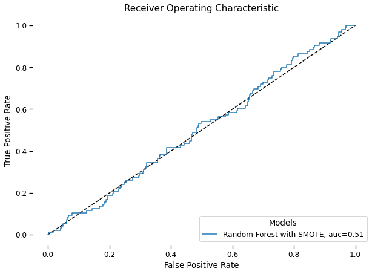

```python
#Plot the ROC

plt.figure(figsize=(10,7))
plt.plot([0, 1], [0, 1], 'k--')

plt.plot(fpr,tpr,label="Random Forest with SMOTE, auc="+str(round(auc,2)))

plt.legend(loc=4, title='Models', facecolor='white')
plt.xlabel('False Positive Rate')
plt.ylabel('True Positive Rate')
plt.title('Receiver Operating Characteristic', size=15)
plt.box(False)
plt.savefig('ImageName', format='png', dpi=200, transparent=True);
```

AUC has decreased by 0.06, not ideal